# Getting Started With ggplot2

11/14/2019

## My Journey With R

- 2000: First course, then forgot about it for many years
- 2014: An Environmental Science course refreshed my memory
- 2016: Lost (deleted?) an Excel file at work, faced a minor crisis, immediately turned back to R
- 2017: Rgronomists began
- ggplot2, tidyverse, RMarkdown, R Projects

## The Grammar of Graphics

[figure not shown]

- Framework for describing component of a graphic and “layering” the structure
- Components include the data, scales, and coordinate system, among other

## More Reading

- Technical Information: https://byrneslab.net/classes/biol607/readings/wickham_layered-grammar.pdf
- Cheat Sheet: https://rstudio.com/wp-content/uploads/2015/03/ggplot2-cheatsheet.pdf

## Getting Started

1. Arrange your dataframe to long format (e.g. using *melt()*)

   https://datacarpentry.org/R-ecology-lesson/03-dplyr.html

## Getting Started

1. Arrange your data to long format
2. Define your aesthetics: define x, y, and any grouping you want to do

## Getting Started

1. Arrange your data to long format
2. Define your aesthetics
3. Indicate how your data should be displayed: geom_bar, geom_line, geom_point, etc.

## Getting Started

1. Arrange your data to long format
2. Define your aesthetics
3. Indicate how your data should be displayed
4. Layer on additional display qualities and design features

## 1. Prepare your data

```r
kable(head(crops_select[, 1:5]), format = "html") %>%
  kable_styling(bootstrap_options = "striped", full_width = T)
```

|  | variable | 1920 | 1925 | 1930 | 1935 |
| --- | --- | --- | --- | --- | --- |
| 36 | CORN | NA | 10906696 | 11047539 | 9857848 |
| 120 | SOYBEANS | NA | NA | 152406 | 862247 |
| 42 | CRP | NA | NA | NA | NA |
| 59 | GRASS | NA | NA | NA | NA |
| 82 | MIXED FORAGE | NA | NA | NA | NA |
| 63 | HayHaylage | 3574726 | 3944354 | 3614599 | 3093410 |

## 1. Prepare your data

```r
#---Prepare dataframe in long format------------------------------------
crops_melt <- melt(crops_select, id.vars = "variable")
names(crops_melt) <- c("Crop", "Year", "Acres")
crops_melt$Year <- as.numeric(as.character(crops_melt$Year))
kable(crops_melt, format = "html") %>%
  kable_styling(bootstrap_options = "striped", full_width = T, font_size = 10)
```

| Crop | Year | Acres |
| --- | --- | --- |
| CORN | 1920 | NA |
| SOYBEANS | 1920 | NA |
| CRP | 1920 | NA |
| GRASS | 1920 | NA |
| MIXED FORAGE | 1920 | NA |
| HayHaylage | 1920 | 3574726.00 |
| ALFALFA | 1920 | NA |
| OATS | 1920 | 5484113.00 |
| COVER CROP | 1920 | NA |
| IDLE | 1920 | NA |
| CORN | 1925 | 10906696.00 |
| SOYBEANS | 1925 | NA |
| CRP | 1925 | NA |
| GRASS | 1925 | NA |
| MIXED FORAGE | 1925 | NA |
| HayHaylage | 1925 | 3944354.00 |
| ALFALFA | 1925 | NA |
| OATS | 1925 | 5702250.00 |
| COVER CROP | 1925 | NA |
| IDLE | 1925 | NA |
| CORN | 1930 | 11047539.00 |
| SOYBEANS | 1930 | 152406.00 |
| CRP | 1930 | NA |
| GRASS | 1930 | NA |
| MIXED FORAGE | 1930 | NA |
| HayHaylage | 1930 | 3614599.00 |
| ALFALFA | 1930 | 456971.00 |
| OATS | 1930 | 5836126.00 |
| COVER CROP | 1930 | NA |
| IDLE | 1930 | NA |

[output cut: 390 more lines]

## 2. Define your aesthetics

```r
plot1 <- ggplot(crops_melt)
```

## 2. Define your aesthetics

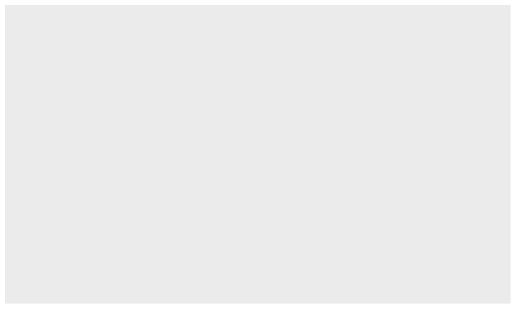

## 2. Define your aesthetics

```r
plot2 <- ggplot(crops_melt,
                aes(x = Year, y = Acres, group = Crop, color = Crop))
```

## 2. Define your aesthetics

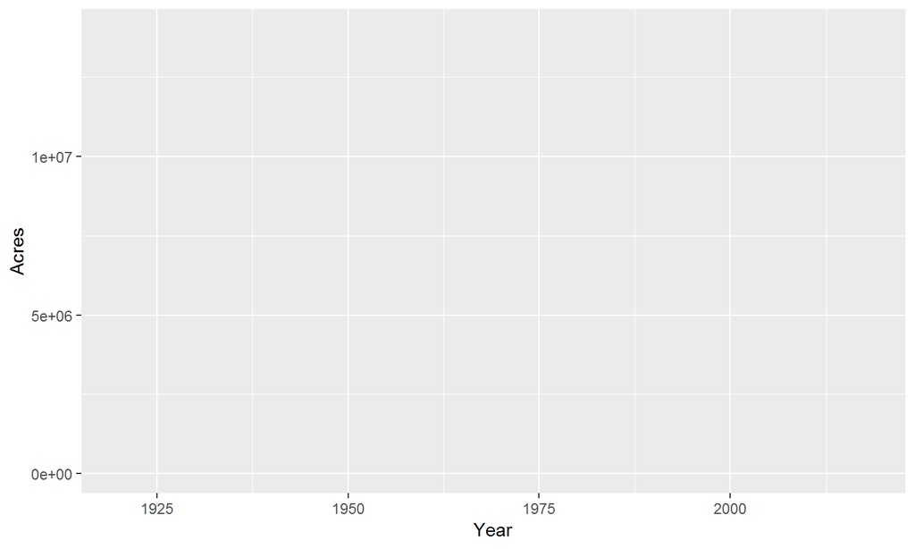

## 3. Indicate how your data should be displayed

```r
plot3 <-
  ggplot(crops_melt,
         aes(x = Year, y = Acres, group = Crop, color = Crop)) +
  geom_line(size = 1, na.rm = T)
```

## 3. Indicate how your data should be displayed

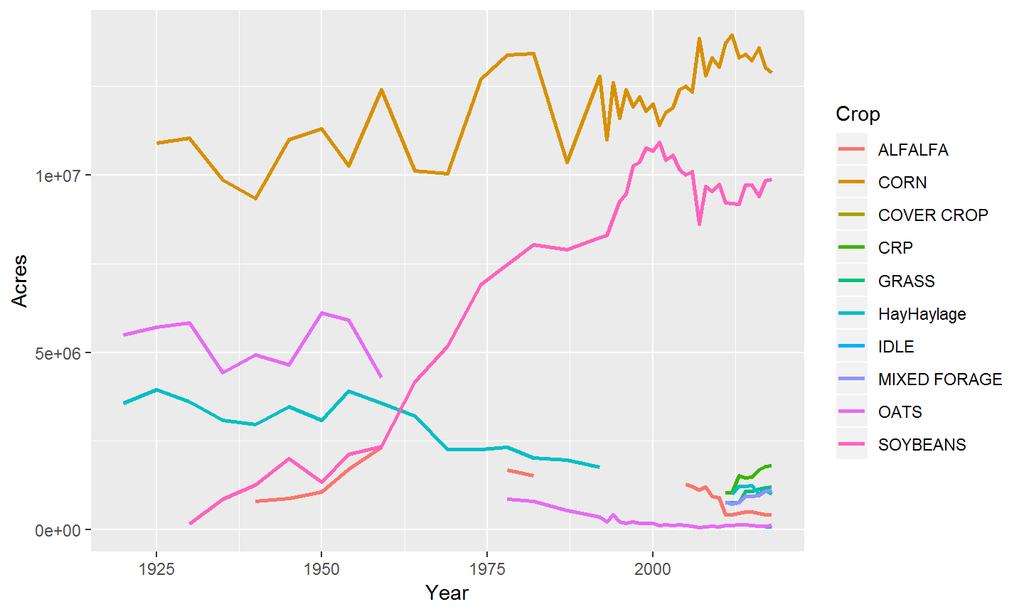

## 4. Layer on additional display qualities and design features

```r
plot4 <-
ggplot(crops_melt,
       aes(x = Year, y = Acres, group = Crop, color = Crop)) +
  geom_line(size = 1, na.rm = T) +
  labs(title = "Iowa Crop Acres, 1920-2018") +
  scale_x_continuous(breaks = seq(1920, 2018, 10),
                     labels = seq(1920, 2018, 10)) +
  scale_y_continuous(breaks = seq(0, 14000000, 2000000),
                     labels = format(seq(0, 14000000, 2000000),
                                     big.mark = ",", scientific = F)) +
  theme_bw()
```

## 4. Layer on additional display qualities and design features

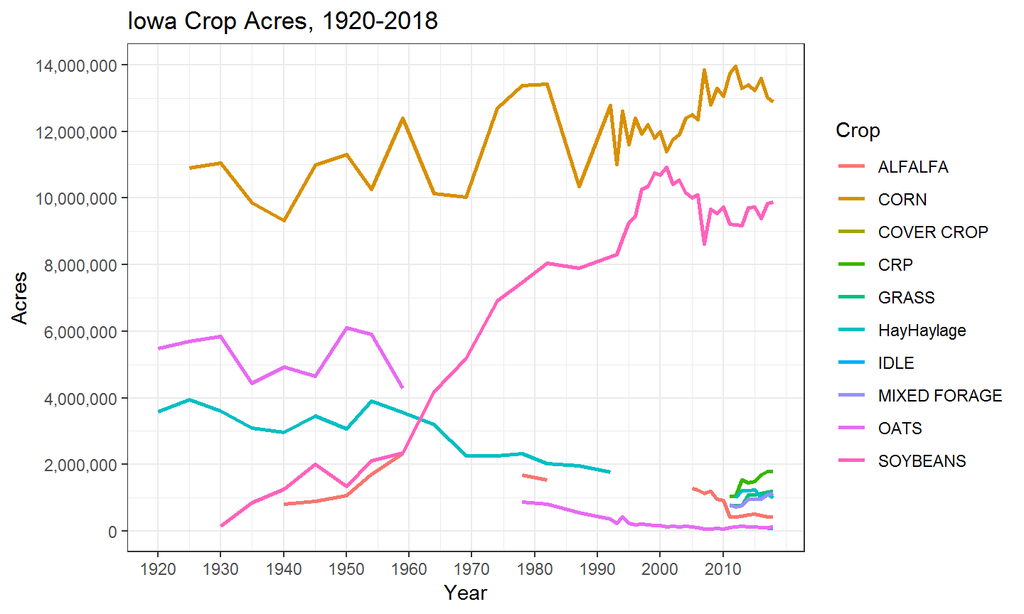

## 4. Layer on additional display qualities and design features

Interesting options:  
- Faceting  
- Using other fonts  
- Exploring other themes

## Hands-On

Create a bar graph to compare different crops’ acreages in 2018. Try a theme other than *theme_bw()*